# Update on Undergraduate Research

Elizabeth Bell and Tyler Netherly

October 18, 2017

**Our Progress** So far we have been focused on visualizing the crop yield dataset in various ways. This choropleth map of Indiana represents everything we have learned about so far in terms of using R and working with the crop data. My map below using the already calculated numbers given in the data for corn yields. Elizabeth has done something similar for bean yields except she calculated her bean yields using acres harvested and total production.

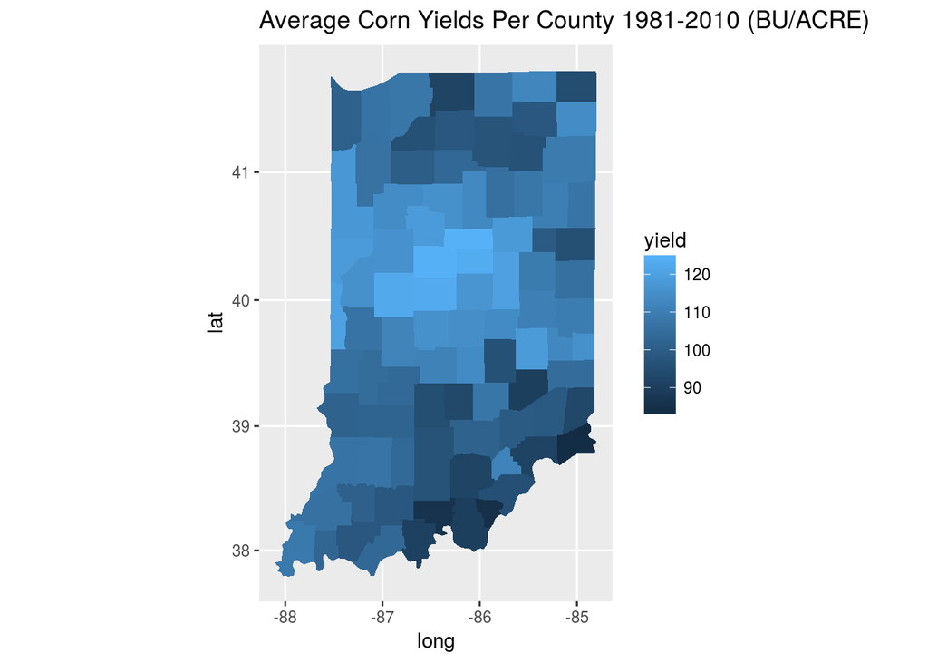

```r
#Loading packages
library(ggplot2)
library(data.table)

#Getting data to IN_field_corn
corn <- read.table("/scratch/mentors/dbuckmas/corn_data.txt", header = TRUE, sep = "\t", fill = TRUE)
field_corn <- subset(corn, COMMODITY_DESC == 'CORN')
IN_field_corn <- subset(field_corn, STATE_NAME == 'INDIANA')

#Getting corn yields
IN_field_corn <- IN_field_corn[IN_field_corn$YEAR >= 1981 & IN_field_corn$YEAR <= 2010, ]
IN_field_corn <- IN_field_corn[ IN_field_corn$SOURCE_DESC == "SURVEY", ]
IN_field_cornyields <- IN_field_corn[ IN_field_corn$SHORT_DESC == "CORN, GRAIN - YIELD, MEASURED IN BU / NET PLANTED ACRE", ]
IN_field_cornyields <- IN_field_cornyields[IN_field_cornyields$AGG_LEVEL_DESC == "COUNTY",]
IN_field_cornyields$COUNTY_NAME <- factor(IN_field_cornyields$COUNTY_NAME)

# Corn Yield Averages
cornyieldmean <- tapply(as.numeric(as.character(gsub(",", ".", IN_field_cornyields$VALUE))), IN_field_cornyields$COUNTY_NAME, mean)

# Getting a list of IN counties
map.county <- map_data('county')
counties <- unique(map.county[,5:6])
incounties <- counties[counties$region == "indiana",]

# Making a map of IN and prepping the data for plotting
yieldmap <- data.frame(state_names = incounties$region,county_names = incounties$subregion, yield = cornyieldmean )
map.county <- data.table(map.county[map.county$region=="indiana",])
setkey(map.county,region,subregion)
yieldmap <- data.table(yieldmap)
setkey(yieldmap,state_names,county_names)
map.df <- map.county[yieldmap]

# Making the map
ggplot(map.df, aes(x=long, y=lat, group = group, fill=yield)) + ggtitle("Average Corn Yields Per County 1981-2010 (BU/ACRE)") + geom_polygon()+coord_map()
```

**What’s Next?** I am currently working on two things. First, I am trying to make a choropleth map of the entire Midwest of corn yields. The hope is this will show some general trends in terms of which area have higher corn yields. A problem I am currently having is, unlike Indiana, not all counties in other Midwestern states have corn yield data available to use. Second, I would like to make a similar map using average rainfall per county for both the entire year and just the months corn is growing. I am hoping that the maps will show that areas that have higher average rainfall tend to grow higher-yielding corn.